# 第五次作业

3018233061 樊一飞

## 1.

从原始函数$y=\frac1{1+x^2},x\in[-5,5]$,随机取二十个点$\{x_i, y_i\}$

```python
y[x_]:=1/(1+x^2)
```

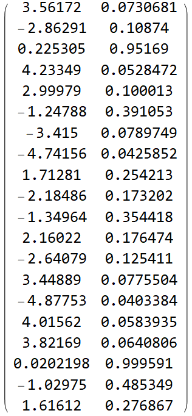

```python
data = Map[Function[x,{x,y[x]}],RandomReal[{-5,5},20]];
data//MatrixForm
```

### (1)

在[-5, 5]的区间，求二十个点的插值多项式 P10(x)和P20(x)，x最高阶为10和20

```python
PolyFit[data_,n_]:=Fit[data,Table[x^i,{i,0,n}],x]
```

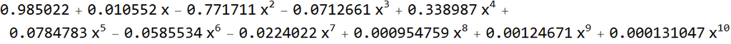

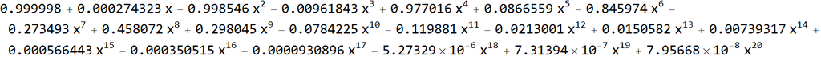

```python
P10 = PolyFit[data,10]
P20 = PolyFit[data,20]
```

### (2)

在同一坐标平面用不同颜色画出P10(x)和P20(x)与原始函数在[-5, 5]的曲线，并将二十个点也画出

[figure not shown]

```python
DataPointPlot = ListPlot[data,PlotStyle->{Red}];
FunctionPlot = Plot[y[x],{x,-5,5},PlotStyle->{Dashed,Green}];
FitPlot = Plot[{P10,P20},{x,-5,5}];
Show[DataPointPlot,FitPlot,FunctionPlot]
```

## 2. 对题目1中重新采集20个数据，试着求分段区间的多项式插值函数

分为三段$(-5,-1),(-1,1),(1,5)$

```python
data1 = Map[Function[x,{x,y[x]}],RandomReal[{-5,-1},7]];
data2 = Map[Function[x,{x,y[x]}],RandomReal[{-1,1},6]];
data3 = Map[Function[x,{x,y[x]}],RandomReal[{1,5},7]];
P1 = PolyFit[data1,3]
P2 = PolyFit[data2,3]
P3 = PolyFit[data3,3]
```

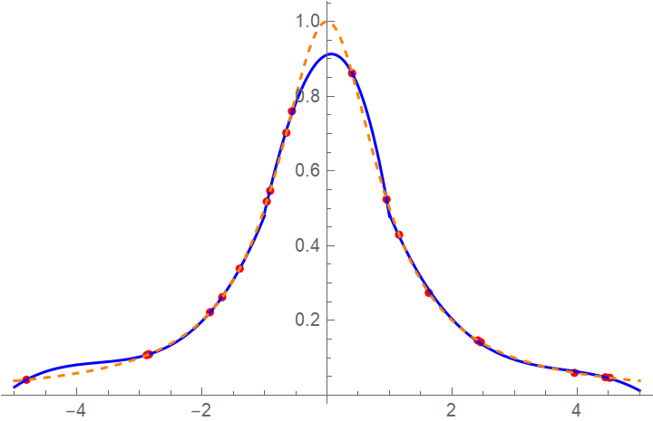

```python
DataPointPlot = ListPlot[{data1,data2,data3},PlotStyle->{Red}];
FunctionPlot = Plot[y[x],{x,-5,5},PlotStyle->{Dashed,Orange}];
P1Plot = Plot[P1,{x,-5,-1},PlotStyle->{Blue}];
P2Plot = Plot[P2,{x,-1,1},PlotStyle->{Blue}];
P3Plot = Plot[P3,{x,1,5},PlotStyle->{Blue}];
Show[DataPointPlot,P1Plot,P2Plot,P3Plot,FunctionPlot,PlotRange->{0,1}]
```

## 3. 对二元函数

$z=\sqrt{(x-2)^2+(y-3)^2}$，在x=0,1,2,3,4以及y=1,2,3,4,5的取值组合出采数据点(x,y,z)。

```python
ClearAll[]
Clear[x,y]
```

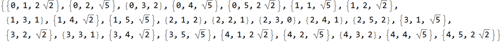

```python
z[x_,y_]:=Sqrt[(x-2)^2+(y-3)^2]
data = Flatten[Table[{x,y,z[x,y]},{x,0,4},{y,1,5}],1]
```

```python
fitZ = Fit[data,Flatten[Table[x^i y^j,{i,0,2},{j,0,2}],1],{x,y}]
```

```python
fitZ/.{x->1.3,y->2.4}
```

```
0.866185
```

(3) 画出插值曲面与原始二元函数曲面 ，并进行比较。

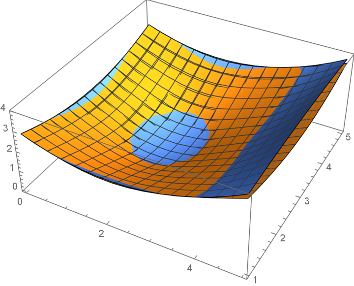

```python
Plot3D[{z[x,y],fitZ},{x,0,5},{y,1,5}]
```

## 4. 从原始函数

$$ y=\frac1{1+e^{-x}} $$

在x轴每隔0.5采一个数据点

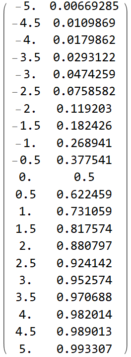

```python
ClearAll[]
y[x_]:= 1/(1+Exp[-x])
data = Table[{x,y[x]},{x,-5,5,.5}];
data//MatrixForm
```

(1) 试着对上述数据点进行多项式插值，画出插值曲面

```python
Fitted = PoltFit[data,5]
```

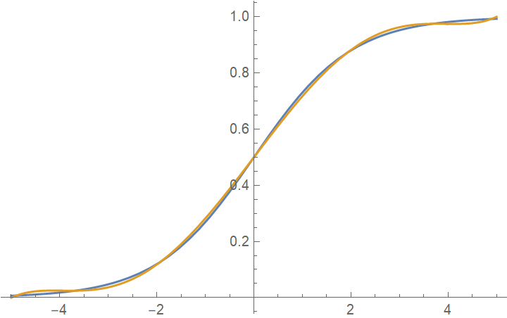

```python
Plot[{y[x],Fitted},{x,-5,5}]
```

(2) 画出上述数据点中各邻近点直接直线相连的线

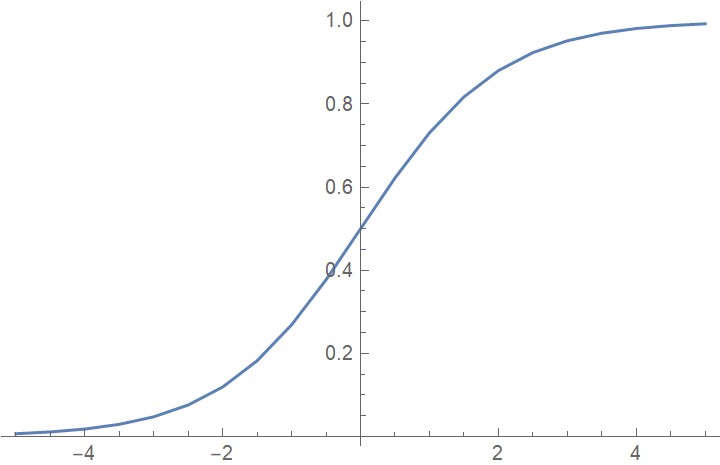

```python
ListLinePlot[data]
```

## 5. 设x的取值为1到50的整数，根据x构造50个点(x,y)其中y为第x个质数

(1) 输出上述50个点；

```python
primes = Table[Prime[x],{x,50}]
```

```
{2, 3, 5, 7, 11, 13, 17, 19, 23, 29, 31, 37, 41, 43, 47, 53, 59, 61, 67, 71, 73, 79, 83,

>   89, 97, 101, 103, 107, 109, 113, 127, 131, 137, 139, 149, 151, 157, 163, 167, 173,

>   179, 181, 191, 193, 197, 199, 211, 223, 227, 229}
```

(2) 用最高三阶多项式进行拟合，并作出点和曲线

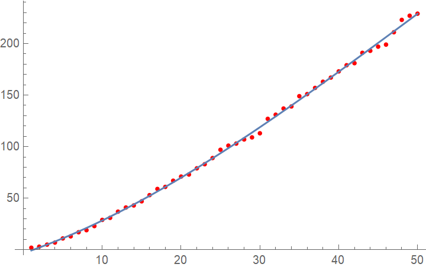

```python
Fitted = PolyFit[primes,3]
Show[ListPlot[primes,PlotStyle->{Red}],Plot[Fitted,{x,1,50}]]
```

(3) 用$a x \log(b+c x)$进行拟合，求出a,b,c，并作出点和曲线

```python
LogFitArgs = FindFit[primes,a x Log[b+c x],{a,b,c},x]
```

[output not shown]

```python
LogFit = a x Log[b+c x] /. LogFitArgs
```

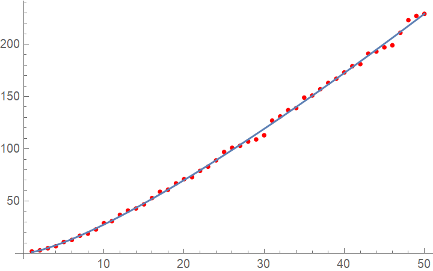

```python
Show[
    ListPlot[primes,PlotStyle->{Red}],
    Plot[LogFit,{x,1,50}]
]
```

(4) 试着求出更好的拟合函数，并作出点和曲线(*). $$ y=ax \log(b+cx+dx^2) $$

```python
LogFitArgs = FindFit[primes,a x Log[b+c x+d x^2],{a,b,c,d},x]
```

```
FindFit::cvmit: Failed to converge to the requested accuracy or precision within 100 iterations.
```

```python
LogFit = a x Log[b+c x+d x^2]/.LogFitArgs
```

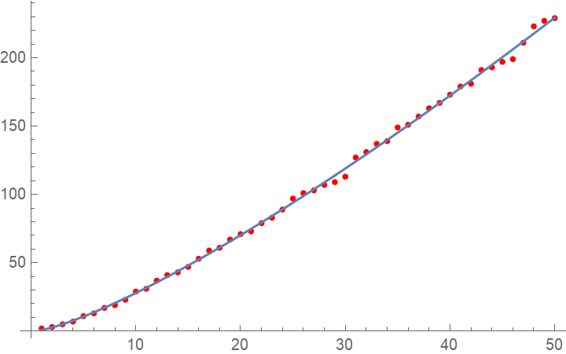

```python
Show[
    ListPlot[primes,PlotStyle->{Red}],
    Plot[LogFit,{x,1,50}]
]
```

## 6. 求解下面的线性规划问题：

(1)

```python
LinearProgramming[
    {-10,-62},
    {{1,1},{7,9},{1,0},{0,1}},
    {{1,1},{63,-1},{6,-1},{5,-1}}
]
```

[output not shown]

(2)

```python
LinearProgramming[
    {-1.5,-2.5},
    {{1,3},{1,1}},
    {1,2}
]
```

```
LinearProgramming::lpsub: This problem is unbounded.
```

## 7. 求解下面的线性规划问题

```python
LinearProgramming[
    {12,8,16,12},
    {{2,1,4,0},{2,2,4,0}},
    {2,3}
]
```

[output not shown]

## 8. 求函数

$$ z=e^{2x}(x+y^2+2y) $$

在区间$[-1, 1]\times[-2, 1]$内的极值

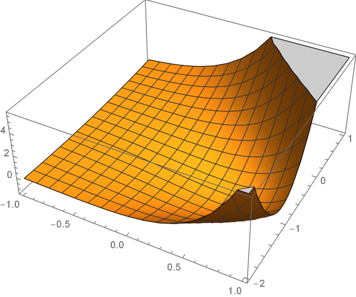

```python
z[x_,y_]:=Exp[2x](x+y^2+2y)
Plot3D[z[x,y],{x,-1,1},{y,-2,1}]
```

```python
MinValue[{z[x,y],-1<=x<=1,-2<=y<=1},{x,y}]
```

[output not shown]

```python
MaxValue[{z[x,y],-1<=x<=1,-2<=y<=1},{x,y}]
```

[output not shown]

## 9. 求函数

$$ f(x,y,z)=x^4+\sin y-\cos z $$

在点（0, 5, 4）附件的极小值

```python
FindMinimum[x^4+Sin[y]-Cos[z],{x,0},{y,5},{z,4}]
```

[output not shown]

## 10. 求下列非线性规划

(1) $\omega=e^{-x^2} \sin 6x$,在x0=1附件的极小点与极小值；

```python
FindMinimum[Exp[-x^2] Sin[6x],{x,1}]
```

[output not shown]

(2) $W$的极小点与极小值

```python
FindMinimum[x1^3+x2^3+x3^3-3(x1+4 x2+9 x3),{x1,x2,x3}]
```

[output not shown]

## 11. 试写出一个函数f(x)，用FindMinimum[f,x]求出来的最小值不是真正的最小值，但是加入初始条件是可以求出真正的最小值。

```python
f[x_]:=x Sin[x]
```

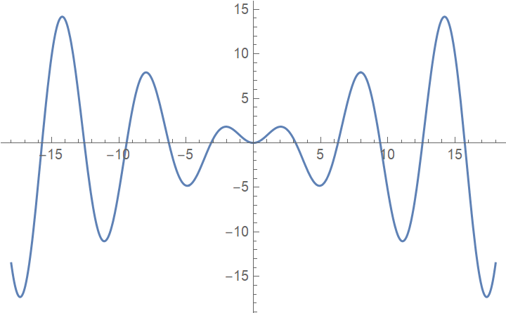

```python
Plot[f[x],{x,-18,18}]
```

```python
FindMaximum[{f[x],-18<=x<=18},x]
```

[output not shown]

```python
FindMaximum[{f[x],-18<=x<=18},{x,-15}]
```

[output not shown]

## 12. 试着通过一些例子来归纳MaxValue，FindMaximum，Maximizate的不同之处

[output not shown]

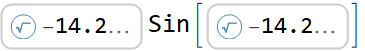

```python
MaxValue[{f[x],-18<=x<=18},x]
```

```python
FindMaximum[{f[x],-18<=x<=18},x]
```

[output not shown]

[output not shown]

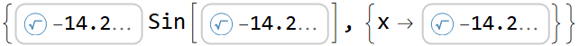

```python
Maximize[{f[x],-18<=x<=18},x]
```

```python
FindMaxValue[{f[x],-18<=x<=18},x]
```

```
1.81971
```

### 异同分析

| 命令 | 功能 | 最优解性质 | 初值依赖性 | 解的类型 | 返回值 |
| --- | --- | --- | --- | --- | --- |
| MaxValue | 求最值 | 全局 | 不依赖 | 精确解 | 最值 |
| Maximizate | 求最值及最值点 | 全局 | 不依赖 | 精确解 | {最值，x->最值点} |
| FindMaxValue | 搜寻极值 | 局部 | 依赖初值的选取 | 近似数值解 | 极值 |
| FindMaximum | 搜寻极值及极值点 | 局部 | 依赖初值的选取 | 近似数值解 | {极值，x->极值点} |

#### 最值与极值

最值在紧集（一般是闭集）内一定存在，但是极值不一定存在

最值不一定是极值，极值也不一定是最值

#### 精确解与数值解

精确解存在不一定可以表示，但数值解存在一定可算